# Exploratory Data Analysis - Reddit Data about Soccer

Author

Jingda Yang, Wendi Chu, Haiyu Xiao, Tingsong Li

## Project Topics

- EDA
  - Business Goal: Evaluate the relative popularity of teams and leagues by ranking the number of posts published between January 2023 and March 2023.
  - Technical Proposal: Develop a manual dictionary that associates major team and league names with their respective subreddit counterparts. Extract Reddit posts from a diverse set of subreddits listed in the dictionary. Subsequently, calculate the post count for each subreddit and visualize the findings using a bar plot.
  - Business Goal: Determine which days of the week see the most activity from soccer fans, and whether this is driven by match days.
  - Technical Proposal: Get external soccer match schedule and data for the same time frame, filter and merge the Reddit activity data with the match schedule data based on the date. Count daily posts and comments in soccer subreddits, flag days with matches using the external database, and assess the relationship between match days and activity spikes. For visualization methods, illustrate the volume of posts/comments over time and compare average daily activity on match days versus non-match days.
  - Business goal: Identify what aspects of soccer are most frequently discussed in different subreddits and what kind of topics are most likely to acquire high scores.
  - Technical proposal: Use NLP to identify the posts that mention different aspects of soccer, including tactics, league policies, transfers or fan culture. Then count the number of posts and calculate the average score of each aspect. Create several plots, like pie charts or bar plots, to visualize the count number and score of the most popular topics.
- NLP
  - Business Goal: Identify the teams or players linked to the highest levels of toxicity in Reddit conversations.
  - Technical Proposal: Create a manual dictionary mapping major team and league names to their respective subreddit names. Gather Reddit posts from a variety of subreddits listed in the dictionary. Establish a processing pipeline to clean and tokenize the text of these posts. Train a toxicity content classifier using a labeled dataset obtained from Kaggle. Apply the trained model to the preprocessed posts and visualize the results using a bar plot.
  - Business Goal: Determine if there is a relationship between the changes of sentiment in soccer subreddits and major events (e.g., wins, losses, transfers).
  - Technical Proposal: Match the Reddit data with key soccer events using dates and team/player mentions. Utilize NLP techniques to assign sentiment scores to each post and comment, and label the dataset with sentiment scores. Investigate sentiment before, during, and after major events. Display sentiment trends over time with event markers.
  - Business goal: Examine how soccer fans feel about the 2022 World Cup, and how their feelings evolve over time.
  - Technical proposal: First extract all the posts relevant to the 2022 World Cup from all the available records. Then apply sentiment analysis for each post to examine the feeling towards the World Cup. Finally track the sentiment over time to see how soccer fans’ feelings change.
- Machine Learning
  - Predict the Popularity of Reddit Posts in Soccer Subreddits, Considering Multiple Factors
  - Technical Proposal: Collect Reddit posts from diverse soccer-related subreddits and analyze various factors, including time of day, day of the week, and the presence of URLs, among others, to forecast a post’s popularity. Convert time-related data into numeric formats and convert categorical label variables, such as URL presence, into binary dummy variables. For the target column, establish a threshold, such as a specified number of comments, to distinguish between popular and non-popular posts, encoding it as a binary variable. Subsequently, develop a classification model to predict the likelihood of a post becoming popular upon submission to Reddit.
  - Business Goal: Predict the outcome of upcoming games based on the sentiment or volume of the discussions before the games.
  - Technical Proposal: Use historical game outcome records to serve as training labels for the model. Merge sentiment and volume metrics with historical game outcomes based on the date and teams playing, and select relevant features that contribute to predictive accuracy (e.g., sentiment score, volume of posts, time series data). Experiment with various ML algorithms (e.g., logistic regression, random forests, SVM, neural networks) to find the best performer, use cross-validation techniques to evaluate model performance. Evaluate the percentage of correct predictions.
  - Business goal: Determine the topics and key words which make a post more controversial.
  - Technical proposal: Extract a sample from the whole records relevant to soccer, and use the controversiality as the dependent variable. Conduct NLP to determine whether each post contains certain topics or key words, and create multiple dummy variables accordingly. Then train a regression model and figure out the features with highest importance.
  - Business goal: Determine whether unsupervised models can be utilized to divide the users into different fan bases.
  - Technical proposal: Apply NLP to extract the posts related to soccer. Then convert the body message into multiple dummy variables indicating the presence and frequency of certain words and topics. Leverage clustering algorithms to divide the unique users into different groups and identify the common features within each group. Examine whether these groups are consistent with the existing fan bases in the world.

```python
#spark
```

```python
import pyspark.sql.functions as f
from pyspark.sql.functions import when, min, max, col
import seaborn as sns
import matplotlib.pyplot as plt
from wordcloud import WordCloud, STOPWORDS
import re
```

**Load Datasets**

```python
workspace_default_storage_account = "group08astoragec0a5c9b39"
workspace_default_container = "azureml-blobstore-8f67895d-e507-48c5-8b8e-f003f0227b44"

workspace_wasbs_base_url = (
    f"wasbs://{workspace_default_container}@{workspace_default_storage_account}.blob.core.windows.net/"
)
df = spark.read.parquet((f"{workspace_wasbs_base_url}<PATH-TO-READ/WRITE>"))
```

```
StatementMeta(8aef2e4c-7819-4b3c-ad3b-441a2f26e87b, 15, 7, Finished, Available)
```

## 1. Basic information exploration

Filter Data Shape: 5617852 x 9.

Filter Data Time Range:  
The minimum created_utc is: 2023-01-01 00:00:00  
The maximun created_utc is: 2023-03-31 23:59:59

Filter Data Schema:  
|– author: string (nullable = true)  
|– author_flair_text: string (nullable = true)  
|– body: string (nullable = true)  
|– controversiality: long (nullable = true)  
|– created_utc: timestamp (nullable = true)  
|– gilded: long (nullable = true)  
|– score: long (nullable = true)  
|– stickied: boolean (nullable = true)  
|– subreddit: string (nullable = true)

## 2. Find out the most popular leagues and clubs on Reddit

```python
# define target subreddits
league_subreddits = ["PremierLeague", "Bundesliga", "seriea", "LaLiga", "MLS", "worldcup"]
club_subreddits = ["chelseafc", "reddevils", "Gunners", "Barca", "realmadrid", "ACMilan", "Juve",
    "ASRoma", "fcbayern", "borussiadortmund", "schalke04", "atletico", "psg", "ajaxAmsterdam",
    "celticfc"]

# filter the dataset with subreddits I would like to explore
df_league = df.filter(df["subreddit"].isin(league_subreddits)).\
    select("subreddit", "controversiality", "score").cache()
df_club = df.filter(df["subreddit"].isin(club_subreddits)).\
    select("subreddit", "controversiality", "score").cache()
```

```
StatementMeta(8aef2e4c-7819-4b3c-ad3b-441a2f26e87b, 11, 11, Finished, Available)
```

```python
# add a column to group the clubs by league
classification_rules = {
    "Premier League": ["chelseafc", "reddevils", "Gunners"],
    "La Liga": ["Barca", "realmadrid", "atletico"],
    "Serie A": ["ACMilan", "Juve", "ASRoma"],
    "Bundesliga": ["fcbayern", "borussiadortmund", "schalke04"],
    "Other": ["psg", "ajaxAmsterdam", "celticfc"]
}

df_club = df_club.withColumn(
    "league",
    when(df_club["subreddit"].isin(classification_rules["Premier League"]), "Premier League")
    .when(df_club["subreddit"].isin(classification_rules["La Liga"]), "La Liga")
    .when(df_club["subreddit"].isin(classification_rules["Serie A"]), "Serie A")
    .when(df_club["subreddit"].isin(classification_rules["Bundesliga"]), "Bundesliga")
    .otherwise("Other"))
```

```
StatementMeta(8aef2e4c-7819-4b3c-ad3b-441a2f26e87b, 11, 12, Finished, Available)
```

```python
# count the number of comments for each league
count_league = df_league.groupBy("subreddit").agg(f.count("*").alias("count")).toPandas().\
    sort_values(by='count', ascending=False)

# count the number of comments for each club
count_club = df_club.groupBy("subreddit", "league").agg(f.count("*").alias("count")).toPandas().\
    sort_values(by='count', ascending=False)
```

```
StatementMeta(8aef2e4c-7819-4b3c-ad3b-441a2f26e87b, 11, 13, Finished, Available)
```

```
StatementMeta(8aef2e4c-7819-4b3c-ad3b-441a2f26e87b, 4, 41, Finished, Available)
```

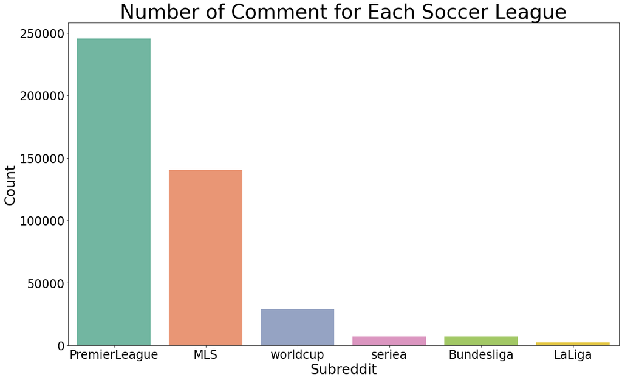

```python
# plot bar plot for the number of comments for leagues
plt.figure(figsize=(20, 12))
sns.barplot(x='subreddit', y='count', data=count_league, palette='Set2')
plt.title('Number of Comment for Each Soccer League', fontsize=40)
plt.xlabel('Subreddit', fontsize=28)
plt.ylabel('Count', fontsize=28)
plt.tick_params(axis='both', labelsize=24)
plt.show()
```

The provided data reveals varying levels of activity across major soccer league subreddits. “PremierLeague” and “MLS” stand out as highly active communities, while “worldcup” also enjoys a substantial presence. In contrast, “seriea,” “Bundesliga,” and “LaLiga” have comparatively lower levels of engagement within their respective subreddits.

```
StatementMeta(8aef2e4c-7819-4b3c-ad3b-441a2f26e87b, 4, 40, Finished, Available)
```

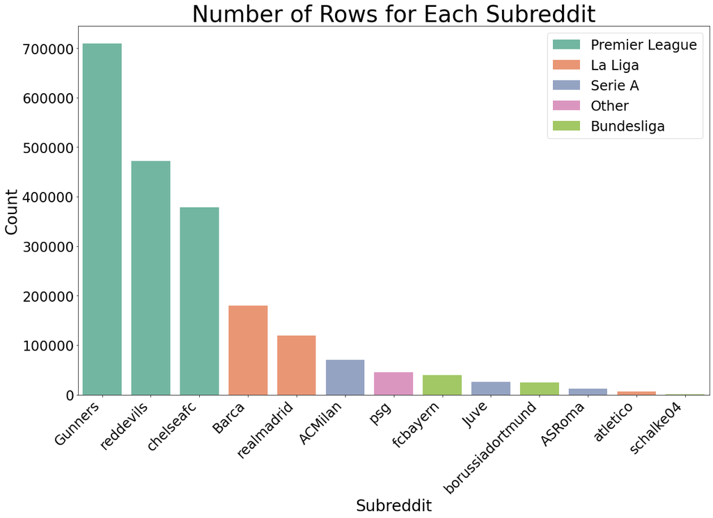

```python
# plot bar plot for the number of comments for clubs
plt.figure(figsize=(20, 12))
sns.barplot(x='subreddit', y='count', hue='league', data=count_club, dodge=False, palette='Set2')
plt.title('Number of Rows for Each Subreddit', fontsize=40)
plt.xlabel('Subreddit', fontsize=28)
plt.ylabel('Count', fontsize=28)
plt.xticks(rotation=45, ha="right")
plt.tick_params(axis='both', labelsize=24)
plt.legend(fontsize=24, loc='upper right')
plt.show()
```

The barplot provides comment counts for popular European soccer clubs (three clubs for Premier League, La Liga, Serie A, and Bundesliga). The Premier League dominates, reflecting active discussions among English club enthusiasts. La Liga’s “Barca” enjoys a robust presence, while Serie A’s “ACMilan” showcases dedicated online discussions. Comparing with Premier League and La Liga, Serie A and Bundesliga are not popular on reddit but major clubs such as Milan and FC Bayern still stand out of the other clubs.

#### Common words of comments on Soccer subreddit

```python
df_soccer = df.filter(df["subreddit"] == "soccer").\
    select("body").cache()
```

```
StatementMeta(8aef2e4c-7819-4b3c-ad3b-441a2f26e87b, 4, 15, Finished, Available)
```

```python
# define a UDF to process each row of text
stopwords = ['s', 'one', 'u'] + list(STOPWORDS)

def process_text(val):
    comment_words = ''

    tokens = val.split()
    for i in range(len(tokens)):
        tokens[i] = tokens[i].lower()
    comment_words += " ".join(tokens) + " "
    return comment_words

process_text_udf = f.udf(process_text)

# apply the UDF to the clean the text
df_soccer = df_soccer.withColumn("comment_words", process_text_udf(f.col("body"))).toPandas()
```

```
StatementMeta(8aef2e4c-7819-4b3c-ad3b-441a2f26e87b, 4, 16, Finished, Available)
```

```
StatementMeta(8aef2e4c-7819-4b3c-ad3b-441a2f26e87b, 4, 39, Finished, Available)
```

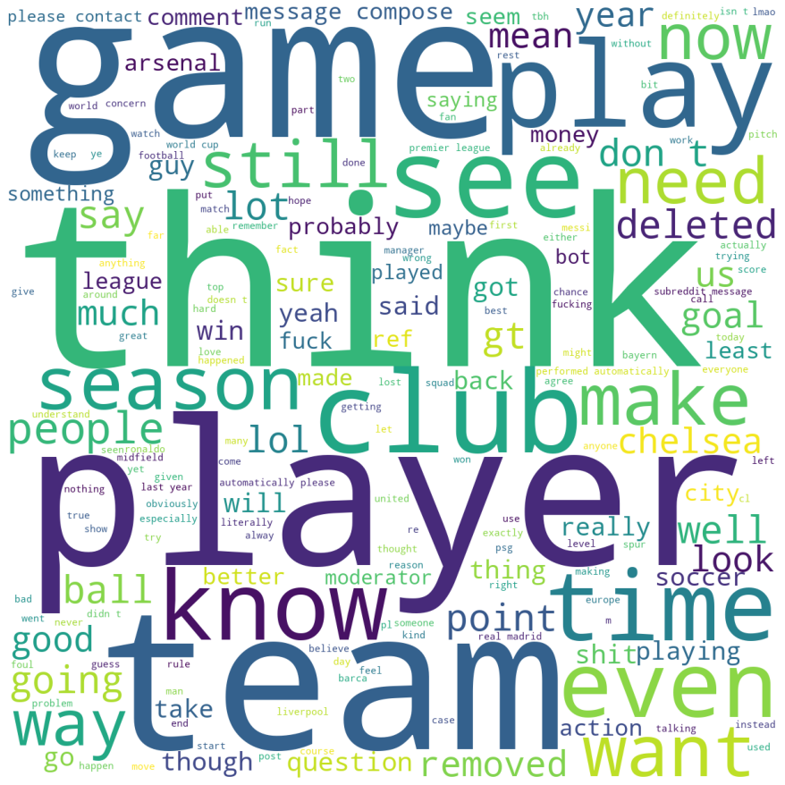

```python
# generate the WordCloud
comment_words = ' '.join(df_soccer['comment_words'].tolist())
wordcloud = WordCloud(width=1200, height=1200, prefer_horizontal=1,
                      background_color='white',
                      stopwords=stopwords,
                      min_font_size=10).generate(comment_words)

plt.figure(figsize=(12, 12), facecolor=None)
plt.imshow(wordcloud)
plt.axis("off")
plt.tight_layout(pad=0)
plt.show()
```

The soccer subreddit word cloud highlights key themes of discussions, such as strategic thinking (“think”), the excitement of the game (“game”), team dynamics (“team” and “club”), and fans’ desires (“want”). Notably, the focus is more on the collective experience of soccer, with only a few specific club mentions like “Arsenal” rather than individual player names. The word “player” suggests a broader discussion of various players across different clubs. Overall, the word cloud reflects a community engaged in analyzing and sharing perspectives on soccer matches, strategies, and the overall team and club experience without emphasizing specific players.

## 3. Determine which days of the week see the most activity from soccer fans, and whether this is driven by match days.

```python
import pandas as pd
```

```
StatementMeta(8aef2e4c-7819-4b3c-ad3b-441a2f26e87b, 13, 11, Finished, Available)
```

### Get the count of comments every day

```python
daily_counts = df.withColumn("date", f.to_date("created_utc")).groupBy("date").count().orderBy("date")
daily_counts.show(5)
```

```
StatementMeta(8aef2e4c-7819-4b3c-ad3b-441a2f26e87b, 13, 12, Finished, Available)
```

```
+----------+-----+
|      date|count|
+----------+-----+
|2023-01-01|56143|
|2023-01-02|63417|
|2023-01-03|69826|
|2023-01-04|66360|
|2023-01-05|61147|
+----------+-----+
only showing top 5 rows
```

```
StatementMeta(8aef2e4c-7819-4b3c-ad3b-441a2f26e87b, 13, 15, Finished, Available)
```

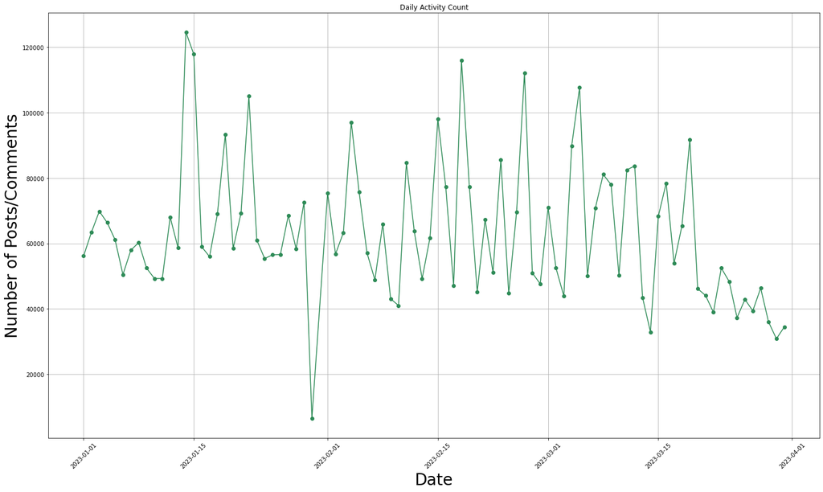

```python
daily_counts_pd = daily_counts.toPandas().sort_values(by="date")
daily_counts_pd['date'] = pd.to_datetime(daily_counts_pd['date'])

plt.figure(figsize=(20, 12))
plt.plot(daily_counts_pd['date'], daily_counts_pd['count'], marker='o', color='seagreen')
plt.title('Daily Activity Count')
plt.xlabel('Date', fontsize=28)
plt.ylabel('Number of Posts/Comments', fontsize=28)
plt.xticks(rotation=45)
plt.grid(True)
plt.tight_layout()

# Show the plot
plt.show()
```

### Read the data frame for the numbers of top leagues matches played each day

```python
df_schedule = pd.read_csv("./Users/hx111/fall-2023-reddit-project-team-08/data/csv/football_schedule.csv")
df_schedule.head()
```

```
StatementMeta(8aef2e4c-7819-4b3c-ad3b-441a2f26e87b, 13, 16, Finished, Available)
```

|  | Date | PremierLeague | LaLiga | Bundesliga | SerieA | Ligue1 | ChampionsLeague |
| --- | --- | --- | --- | --- | --- | --- | --- |
| 0 | 1/1/2023 | 2 | 0 | 0 | 0 | 6 | 0 |
| 1 | 1/2/2023 | 1 | 0 | 0 | 0 | 4 | 0 |
| 2 | 1/3/2023 | 4 | 0 | 0 | 0 | 0 | 0 |
| 3 | 1/4/2023 | 4 | 0 | 0 | 10 | 0 | 0 |
| 4 | 1/5/2023 | 1 | 0 | 0 | 0 | 0 | 0 |

```python
# Data cleaning
df_schedule['date'] = pd.to_datetime(df_schedule['Date'])
df_schedule['date'] = df_schedule['date'].dt.strftime('%Y-%m-%d')
df_schedule['date'] = pd.to_datetime(df_schedule['date'])
df_schedule.drop('Date', axis=1, inplace=True)
cols = ['date'] + [col for col in df_schedule if col != 'date']
df_schedule = df_schedule[cols]
df_schedule['TotalMatches'] = df_schedule.iloc[:, 1:7].sum(axis=1)
df_schedule.head()
```

```
StatementMeta(8aef2e4c-7819-4b3c-ad3b-441a2f26e87b, 13, 17, Finished, Available)
```

|  | date | PremierLeague | LaLiga | Bundesliga | SerieA | Ligue1 | ChampionsLeague | TotalMatches |
| --- | --- | --- | --- | --- | --- | --- | --- | --- |
| 0 | 2023-01-01 | 2 | 0 | 0 | 0 | 6 | 0 | 8 |
| 1 | 2023-01-02 | 1 | 0 | 0 | 0 | 4 | 0 | 5 |
| 2 | 2023-01-03 | 4 | 0 | 0 | 0 | 0 | 0 | 4 |
| 3 | 2023-01-04 | 4 | 0 | 0 | 10 | 0 | 0 | 14 |
| 4 | 2023-01-05 | 1 | 0 | 0 | 0 | 0 | 0 | 1 |

### Data Visualizations: explore whether there is a relationship between the daily comments counts and the number of top league matches played

```python
# First, merge the dataframes of the daily comments count and daily matches count
merged_df = pd.merge(daily_counts_pd, df_schedule, on='date', how='outer')
merged_df.fillna(0, inplace=True)

date_range = pd.date_range(start=merged_df['date'].min(), end=merged_df['date'].max())
merged_df.set_index('date', inplace=True)
merged_df = merged_df.reindex(date_range, fill_value=0).reset_index()
merged_df.rename(columns={'index': 'date'}, inplace=True)
merged_df.head()
```

```
StatementMeta(8aef2e4c-7819-4b3c-ad3b-441a2f26e87b, 13, 18, Finished, Available)
```

|  | date | count | PremierLeague | LaLiga | Bundesliga | SerieA | Ligue1 | ChampionsLeague | TotalMatches |
| --- | --- | --- | --- | --- | --- | --- | --- | --- | --- |
| 0 | 2023-01-01 | 56143.0 | 2 | 0 | 0 | 0 | 6 | 0 | 8 |
| 1 | 2023-01-02 | 63417.0 | 1 | 0 | 0 | 0 | 4 | 0 | 5 |
| 2 | 2023-01-03 | 69826.0 | 4 | 0 | 0 | 0 | 0 | 0 | 4 |
| 3 | 2023-01-04 | 66360.0 | 4 | 0 | 0 | 10 | 0 | 0 | 14 |
| 4 | 2023-01-05 | 61147.0 | 1 | 0 | 0 | 0 | 0 | 0 | 1 |

### Line chart

```
StatementMeta(8aef2e4c-7819-4b3c-ad3b-441a2f26e87b, 13, 19, Finished, Available)
```

[figure not shown]

```python
fig, ax1 = plt.subplots(figsize=(20, 12))

# Plot the first data series (Reddit Comments) on ax1
color = 'seagreen'
ax1.set_xlabel('Date', fontsize=28)
ax1.set_ylabel('Number of Reddit Comments', color=color, fontsize=28)
ax1.plot(merged_df['date'], merged_df['count'], label='Reddit Comments', marker='o', color=color)
ax1.tick_params(axis='y', labelsize=24)
ax1.tick_params(axis='x', rotation=45, labelsize=24)

# Create a second y-axis for the second data series (Number of Matches)
ax2 = ax1.twinx()
ax2.set_ylim(0, (merged_df['TotalMatches'].max()) * 2)
color = 'darkorange'
ax2.set_ylabel('Number of Matches', color=color, fontsize=28)
ax2.plot(merged_df['date'], merged_df['TotalMatches'], label='Number of Matches', marker='x', color=color)
ax2.tick_params(axis='y', labelsize=24)

# Title and grid
plt.title('Daily Number of Reddit Comments vs. Number of Matches', fontsize=40)
plt.grid(False)

# Save the plot
# plt.savefig('./Users/hx111/fall-2023-reddit-project-team-08/data/plots/daily_comments_matches.png')

# Show the plot
plt.show()
```

### Bar chart

```python
# Get the weekdays for thedate in the merged dataframe
merged_df['weekday'] = merged_df['date'].dt.day_name()
merged_df.head()
```

```
StatementMeta(8aef2e4c-7819-4b3c-ad3b-441a2f26e87b, 13, 20, Finished, Available)
```

|  | date | count | PremierLeague | LaLiga | Bundesliga | SerieA | Ligue1 | ChampionsLeague | TotalMatches | weekday |
| --- | --- | --- | --- | --- | --- | --- | --- | --- | --- | --- |
| 0 | 2023-01-01 | 56143.0 | 2 | 0 | 0 | 0 | 6 | 0 | 8 | Sunday |
| 1 | 2023-01-02 | 63417.0 | 1 | 0 | 0 | 0 | 4 | 0 | 5 | Monday |
| 2 | 2023-01-03 | 69826.0 | 4 | 0 | 0 | 0 | 0 | 0 | 4 | Tuesday |
| 3 | 2023-01-04 | 66360.0 | 4 | 0 | 0 | 10 | 0 | 0 | 14 | Wednesday |
| 4 | 2023-01-05 | 61147.0 | 1 | 0 | 0 | 0 | 0 | 0 | 1 | Thursday |

```python
# Group by 'weekday' and calculate mean
weekday_avg = merged_df.groupby('weekday')[['count', 'TotalMatches']].mean().reset_index()

# Reorder the days of the week
order = ["Monday", "Tuesday", "Wednesday", "Thursday", "Friday", "Saturday", "Sunday"]
weekday_avg['weekday'] = pd.Categorical(weekday_avg['weekday'], categories=order, ordered=True)
weekday_avg = weekday_avg.sort_values('weekday')
```

```
StatementMeta(8aef2e4c-7819-4b3c-ad3b-441a2f26e87b, 13, 21, Finished, Available)
```

```python
import numpy as np

# Number of categories (weekdays)
n_categories = len(weekday_avg['weekday'])

# Positions of the first set of bars
pos = np.arange(n_categories)

# Width of a bar
width = 0.35
```

```
StatementMeta(8aef2e4c-7819-4b3c-ad3b-441a2f26e87b, 13, 22, Finished, Available)
```

```
StatementMeta(8aef2e4c-7819-4b3c-ad3b-441a2f26e87b, 13, 23, Finished, Available)
```

[figure not shown]

```python
plt.rcdefaults()

fig, ax1 = plt.subplots(figsize=(20, 12))

# Bar plot for the number of Reddit comments
rects1 = ax1.bar(pos - width/2, weekday_avg['count'], width, label='Reddit Comments', color='seagreen')

# Create the second y-axis
ax2 = ax1.twinx()

# Bar plot for the number of matches on the second y-axis
rects2 = ax2.bar(pos + width/2, weekday_avg['TotalMatches'], width, label='Number of Matches', color='darkorange')

# Labels, title, and custom x-axis tick labels
ax1.set_xlabel('Weekday', fontsize=28)
ax1.set_ylabel('Average Number of Reddit Comments', color='seagreen', fontsize=28)
ax2.set_ylabel('Average Number of Matches', color='darkorange', fontsize=28)
ax1.set_xticks(pos)
ax1.set_xticklabels(weekday_avg['weekday'], fontsize=24)
# Set the y-tick labels font size for ax1
for label in ax1.get_yticklabels():
    label.set_fontsize(24)

# Set the y-tick labels font size for ax2
for label in ax2.get_yticklabels():
    label.set_fontsize(24)
ax1.tick_params(axis='y', labelcolor='black')
ax2.tick_params(axis='y', labelcolor='black')
plt.title('Average Number of Reddit Comments and Matches by Weekday', fontsize=40)

# Legends
ax1.legend(loc='upper left', fontsize=24)
ax2.legend(loc='upper right', fontsize=24)

# Save the plot
# plt.savefig('./Users/hx111/fall-2023-reddit-project-team-08/data/plots/weekday_comments_matches.png')

# Show the plot
plt.show()
```

## 4. Identify what aspects of soccer are most frequently discussed in different subreddits and what kind of topics are most likely to acquire high scores.

For this problem, I choose 6 different topics which are commonly discussed in soccer forum: - Soccer tactics - Transfers - Player performances - Player rankings - Match analysis and previews - Managerial decisions

For each topic, I define a series of relevant keywords. Then I search for these keywords in the ‘body’ column to determine whether each post relates to a certain topic. Six dummy variables are created to display whether each post contains information or each topic: ‘soccer_tactics’, ‘transfers’, ‘player_performances’, ‘player_rankings’, ‘match_analysis_previews’, ‘managerial_decisions’. Next, it is possible for us to calculate the total number, average score, and gild percentage of each topic. Eventually, I create several visualizations to display the data output.

```python
from pyspark.sql.functions import when, col, regexp_extract
import pyspark.sql.functions as f
import pandas as pd
import matplotlib.pyplot as plt
import seaborn as sns
```

```
StatementMeta(8aef2e4c-7819-4b3c-ad3b-441a2f26e87b, 15, 8, Finished, Available)
```

```python
# Define the keywords for each topic
tactics_keywords = '|'.join(['tactic', 'formation', 'playstyle', 'strategy', 'lineup', 'set-piece', 'defense', 'offense', 'pressing', 'counter-attack', 'tiki-taka', 'tikitaka', '433', '442', '4-3-3', '4-4-2'])
transfers_keywords = '|'.join(['transfer', 'signing', 'contract', 'bid', 'deal', 'release clause', 'agent', 'loan', 'free transfer', 'termination fee'])
performances_keywords = '|'.join(['goal', 'assist', 'save', 'tackle', 'dribble', 'performance', 'man of the match', 'rating', 'brace', 'hat trick'])
rankings_keywords = '|'.join(['rankings', 'top scorer', 'best midfielder', 'best defender' 'leaderboard', 'award', 'Ballon d\'Or', 'FIFA Best', 'talent', 'prospect', 'goat', 'g.o.a.t', 'greatest', 'top 10', 'top 30'])
analysis_keywords = '|'.join(['preview', 'analysis', 'derby', 'fixture', 'head-to-head', 'odds', 'prediction', 'review', 'recap', 'post-match', 'highlight'])
decisions_keywords = '|'.join(['manager', 'coach', 'substitution', 'tactics', 'selection', 'bench', 'formation change', 'press conference', 'interview'])
```

```
StatementMeta(8aef2e4c-7819-4b3c-ad3b-441a2f26e87b, 15, 9, Finished, Available)
```

```python
# Add columns with dummy variables for each topic based on the presence of keywords
df_with_topics = df.withColumn('soccer_tactics', when(col('body').rlike(tactics_keywords), 1).otherwise(0)) \
                   .withColumn('transfers', when(col('body').rlike(transfers_keywords), 1).otherwise(0)) \
                   .withColumn('player_performances', when(col('body').rlike(performances_keywords), 1).otherwise(0)) \
                   .withColumn('player_rankings', when(col('body').rlike(rankings_keywords), 1).otherwise(0)) \
                   .withColumn('match_analysis_previews', when(col('body').rlike(analysis_keywords), 1).otherwise(0)) \
                   .withColumn('managerial_decisions', when(col('body').rlike(decisions_keywords), 1).otherwise(0))
```

```
StatementMeta(8aef2e4c-7819-4b3c-ad3b-441a2f26e87b, 15, 10, Finished, Available)
```

```python
# Filter the DataFrame to only keep records that are related to at least one topic
df_filtered = df_with_topics.filter(
    (col('soccer_tactics') == 1) |
    (col('transfers') == 1) |
    (col('player_performances') == 1) |
    (col('player_rankings') == 1) |
    (col('match_analysis_previews') == 1) |
    (col('managerial_decisions') == 1)
)
```

```
StatementMeta(8aef2e4c-7819-4b3c-ad3b-441a2f26e87b, 15, 11, Finished, Available)
```

```python
# Only keep the columns we want for this problem
df_filtered = df_filtered.select('body', 'gilded', 'score', 'soccer_tactics', 'transfers', 'player_performances',\
'player_rankings', 'match_analysis_previews', 'managerial_decisions')
```

```
StatementMeta(8aef2e4c-7819-4b3c-ad3b-441a2f26e87b, 15, 12, Finished, Available)
```

```python
df_filtered.printSchema()
```

```
StatementMeta(8aef2e4c-7819-4b3c-ad3b-441a2f26e87b, 15, 13, Finished, Available)
```

```
root
 |-- body: string (nullable = true)
 |-- gilded: long (nullable = true)
 |-- score: long (nullable = true)
 |-- soccer_tactics: integer (nullable = false)
 |-- transfers: integer (nullable = false)
 |-- player_performances: integer (nullable = false)
 |-- player_rankings: integer (nullable = false)
 |-- match_analysis_previews: integer (nullable = false)
 |-- managerial_decisions: integer (nullable = false)
```

```python
datapath = 'Users/wc777/fall-2023-reddit-project-team-08/data'
df_filtered.write.parquet(f"{datapath}/csv/soccer_topic.parquet")
```

```python
# Calculate the number of row, average score, and number of gilded posts within each topic
topic_counts = df_filtered.groupBy().agg(
    f.sum('soccer_tactics').alias('soccer_tactics_count'),
    f.sum('transfers').alias('transfers_count'),
    f.sum('player_performances').alias('player_performances_count'),
    f.sum('player_rankings').alias('player_rankings_count'),
    f.sum('match_analysis_previews').alias('match_analysis_previews_count'),
    f.sum('managerial_decisions').alias('managerial_decisions_count'),
    f.round(f.avg(f.when(col('soccer_tactics') == 1, col('score'))), 2).alias('avg_score_soccer_tactics'),
    f.round(f.avg(f.when(col('transfers') == 1, col('score'))), 2).alias('avg_score_transfers'),
    f.round(f.avg(f.when(col('player_performances') == 1, col('score'))), 2).alias('avg_score_player_performances'),
    f.round(f.avg(f.when(col('player_rankings') == 1, col('score'))), 2).alias('avg_score_player_rankings'),
    f.round(f.avg(f.when(col('match_analysis_previews') == 1, col('score'))), 2).alias('avg_score_match_analysis_previews'),
    f.round(f.avg(f.when(col('managerial_decisions') == 1, col('score'))), 2).alias('avg_score_managerial_decisions'),
    f.sum(when((col('soccer_tactics') == 1) & (col('gilded') != 0), 1)).alias('gilded_soccer_tactics'),
    f.sum(when((col('transfers') == 1) & (col('gilded') != 0), 1)).alias('gilded_transfers'),
    f.sum(when((col('player_performances') == 1) & (col('gilded') != 0), 1)).alias('gilded_player_performances'),
    f.sum(when((col('player_rankings') == 1) & (col('gilded') != 0), 1)).alias('gilded_player_rankings'),
    f.sum(when((col('match_analysis_previews') == 1) & (col('gilded') != 0), 1)).alias('gilded_match_analysis_previews'),
    f.sum(when((col('managerial_decisions') == 1) & (col('gilded') != 0), 1)).alias('gilded_managerial_decisions')
)
```

```
StatementMeta(8aef2e4c-7819-4b3c-ad3b-441a2f26e87b, 15, 18, Finished, Available)
```

```python
topic_counts_pd = topic_counts.toPandas()
```

```
StatementMeta(8aef2e4c-7819-4b3c-ad3b-441a2f26e87b, 15, 19, Finished, Available)
```

```python
# Convert the wide table to a long table

topics = {
    'soccer_tactics': 'Soccer Tactics',
    'transfers': 'Transfers',
    'player_performances': 'Player Performances',
    'player_rankings': 'Player Rankings',
    'match_analysis_previews': 'Match Analysis and Previews',
    'managerial_decisions': 'Managerial Decisions'
}

rows = []
for topic_key, topic_name in topics.items():
    row = {
        'topic': topic_name,
        'number of rows': topic_counts_pd[topic_key + '_count'].iloc[0],
        'average score': topic_counts_pd['avg_score_' + topic_key].iloc[0],
        'gild percentage (%)': round(topic_counts_pd['gilded_' + topic_key].iloc[0]/topic_counts_pd[topic_key + '_count'].iloc[0]\
        *100, 3)
    }
    rows.append(row)

pd_for_plot = pd.DataFrame(rows)
```

```
StatementMeta(8aef2e4c-7819-4b3c-ad3b-441a2f26e87b, 15, 38, Finished, Available)
```

```python
pd_for_plot
```

```
StatementMeta(8aef2e4c-7819-4b3c-ad3b-441a2f26e87b, 15, 39, Finished, Available)
```

|  | topic | number of rows | average score | gild percentage (%) |
| --- | --- | --- | --- | --- |
| 0 | Soccer Tactics | 104584 | 12.28 | 0.030 |
| 1 | Transfers | 224669 | 16.02 | 0.024 |
| 2 | Player Performances | 327807 | 15.93 | 0.053 |
| 3 | Player Rankings | 75402 | 15.37 | 0.036 |
| 4 | Match Analysis and Previews | 44770 | 15.12 | 0.054 |
| 5 | Managerial Decisions | 184505 | 15.89 | 0.027 |

```python
pd_for_plot.to_csv(f'{datapath}/csv/soccer_topic_summary.csv', index=False)
```

### Barplot: Number of Rows per Topic

```
StatementMeta(8aef2e4c-7819-4b3c-ad3b-441a2f26e87b, 15, 40, Finished, Available)
```

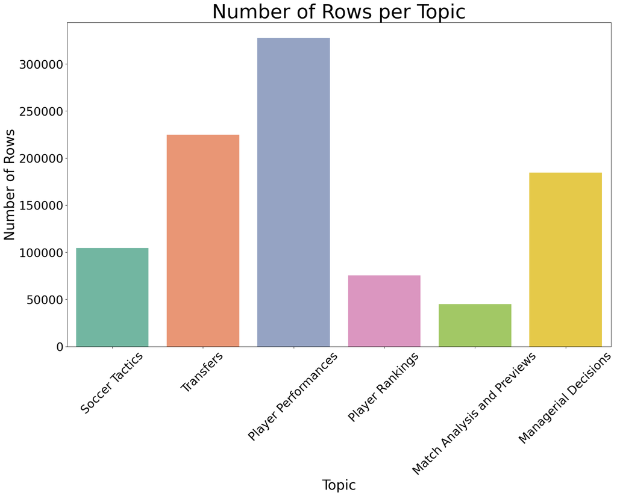

```python
sns.reset_defaults()
plt.rcdefaults()

plt.figure(figsize=(20, 12))

sns.barplot(x='topic', y='number of rows', data=pd_for_plot, palette='Set2')
plt.title('Number of Rows per Topic', fontsize=40)
plt.xlabel('Topic', fontsize=28)
plt.ylabel('Number of Rows', fontsize=28)
plt.tick_params(axis='both', labelsize=24)
plt.xticks(rotation=45)
# plt.savefig('./Users/wc777/fall-2023-reddit-project-team-08/data/plots/number_of_rows_bar.png')
plt.show()
```

### Pie chart: Proportion of Posts per Topic

```
StatementMeta(8aef2e4c-7819-4b3c-ad3b-441a2f26e87b, 15, 45, Finished, Available)
```

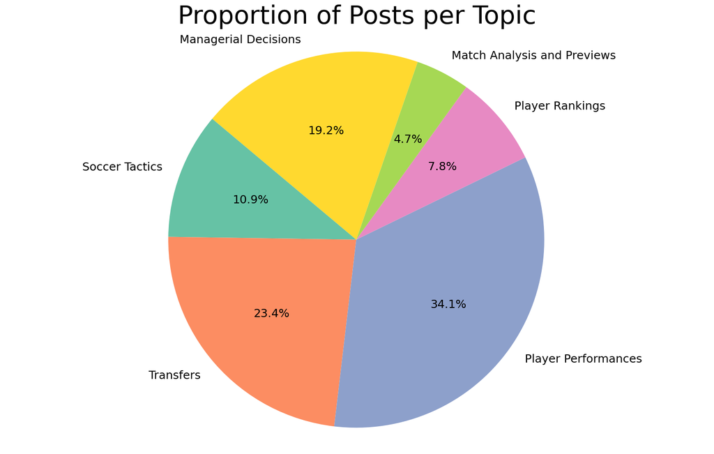

```python
sizes = pd_for_plot['number of rows']
labels = pd_for_plot['topic']

# Plot pie chart
plt.figure(figsize=(20, 12))
plt.pie(sizes, labels=labels, autopct='%1.1f%%', startangle=140, colors=sns.color_palette('Set2'),
    textprops={'fontsize': 18})
plt.title('Proportion of Posts per Topic', fontsize=40)
plt.axis('equal')

# plt.savefig('./Users/wc777/fall-2023-reddit-project-team-08/data/plots/proportion_of_topics_pie.png')
plt.show()
```

According to these two charts above, we can observe that Player Performances is the hottest topic in the Reddit posts related to soccer, while Match Analysis and Previews is discussed less frequently compared to other topics.

### Barplot: Average Score per Topic

```
StatementMeta(8aef2e4c-7819-4b3c-ad3b-441a2f26e87b, 15, 41, Finished, Available)
```

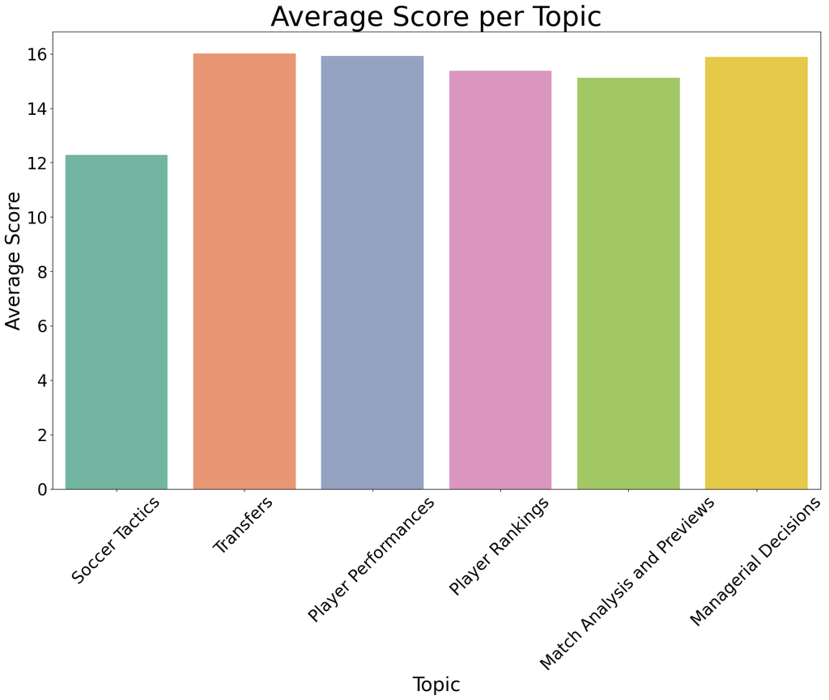

```python
plt.figure(figsize=(20, 12))
sns.barplot(x='topic', y='average score', data=pd_for_plot, palette='Set2')
plt.title('Average Score per Topic', fontsize=40)
plt.xlabel('Topic', fontsize=28)
plt.ylabel('Average Score', fontsize=28)
plt.tick_params(axis='both', labelsize=24)
plt.xticks(rotation=45)
# plt.savefig('./Users/wc777/fall-2023-reddit-project-team-08/data/plots/average_score_bar.png')
plt.show()
```

From this plot, we can conclude that the average score of posts related to Soccer Tactics is significantly lower than other topics, whereas the average scores of other five topics are quite similar. This suggests that users on Reddit are not so interested in the posts related to Soccer Tactics compared to other topics about soccer.

### Barplot: Gild Percentage per Topic

```
StatementMeta(8aef2e4c-7819-4b3c-ad3b-441a2f26e87b, 15, 43, Finished, Available)
```

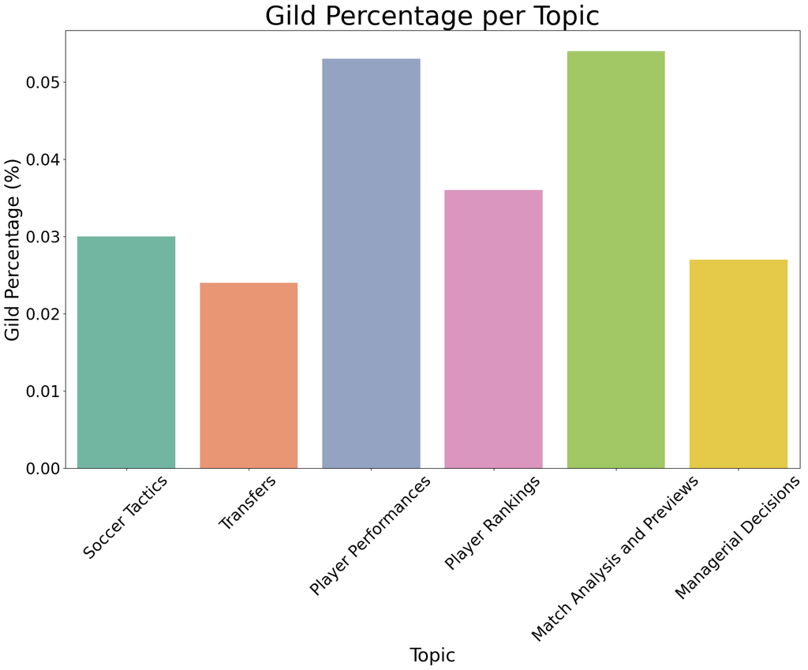

```python
plt.figure(figsize=(20, 12))
sns.barplot(x='topic', y='gild percentage (%)', data=pd_for_plot, palette='Set2')
plt.title('Gild Percentage per Topic', fontsize=40)
plt.xlabel('Topic', fontsize=28)
plt.ylabel('Gild Percentage (%)', fontsize=28)
plt.tick_params(axis='both', labelsize=24)
plt.xticks(rotation=45)
# plt.savefig('./Users/wc777/fall-2023-reddit-project-team-08/data/plots/gild_percentage_bar.png')
plt.show()
```

Unlike the average score distribution of each topic, the gild percentage of the topics show greater variety. Posts related to Player Performances or Match Analysis and Previews tend to have higher probabilities to be gilded. Also, it is interesting that although the number of posts about Match Analysis and Previews are smaller than other topics, the gild percentage of this topic is the highest among all.